# Lesson 3

### What to Do First?

Notes: What is the goal ? What questions are you trying to answer ?

### Pseudo-Facebook User Data

Notes: Loaded Data

```r
pf <- read.csv('./pseudo_facebook.tsv', sep = '\t')
names(pf)
```

```
##  [1] "userid"                "age"
##  [3] "dob_day"               "dob_year"
##  [5] "dob_month"             "gender"
##  [7] "tenure"                "friend_count"
##  [9] "friendships_initiated" "likes"
## [11] "likes_received"        "mobile_likes"
## [13] "mobile_likes_received" "www_likes"
## [15] "www_likes_received"
```

### Histogram of Users’ Birthdays

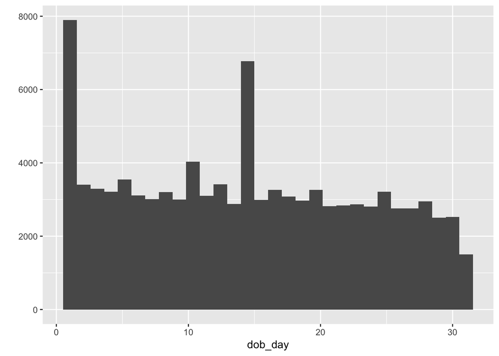

```r
# install.packages('ggplot2')
library(ggplot2)
# install.packages('ggthemes', dependencies = TRUE)
library(ggthemes)
qplot(data = pf, x = dob_day)
```

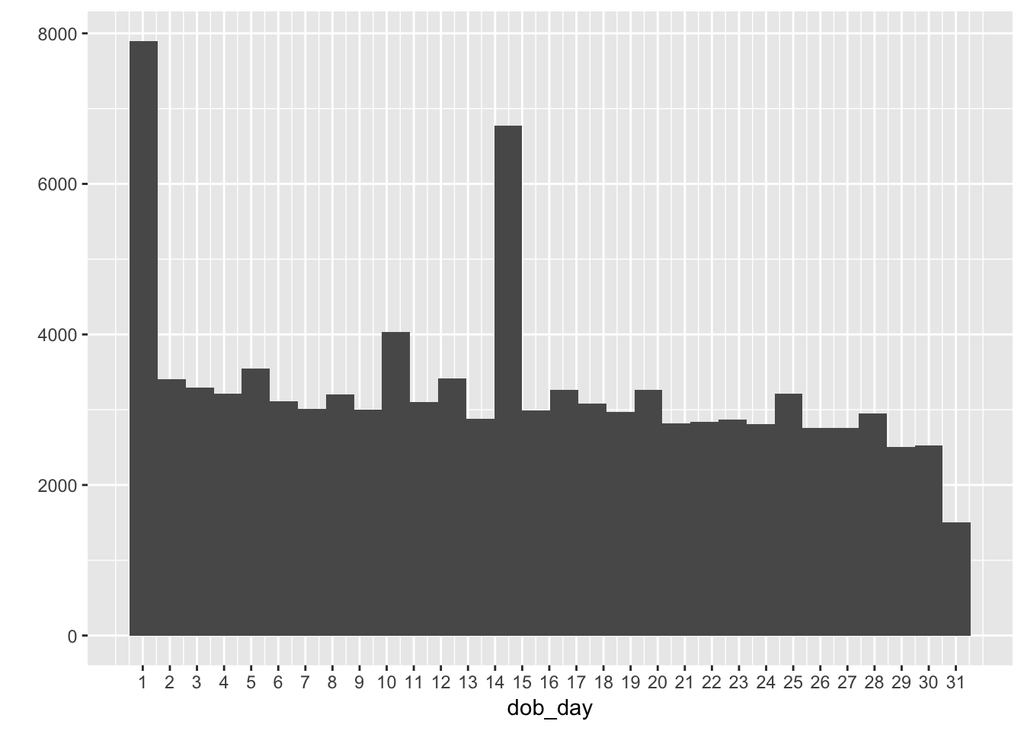

```r
qplot(data = pf, x = dob_day) +
  scale_x_continuous(breaks = 1:31)
```

### Moira’s Investigation

Notes: Perception of audience on Facebook. How many people view your posts on Facebook ? A project was tackling this problem.

### Faceting

Notes:

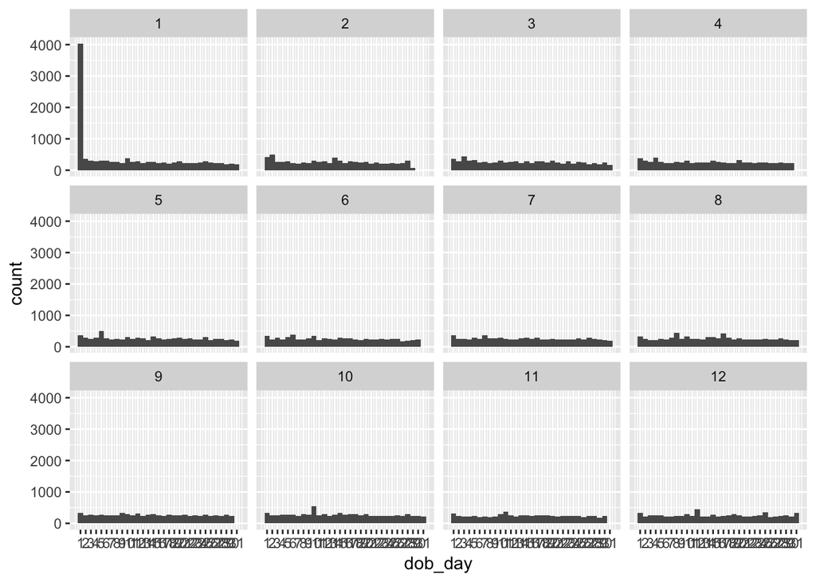

```r
ggplot(data = pf, aes(x = dob_day)) +
  geom_histogram(binwidth = 1) +
  scale_x_continuous(breaks = 1:31) +
  facet_wrap(~dob_month)
```

#### Let’s take another look at our plot. What stands out to you here?

Response: More people have birthdays on the first of January

### Be Skeptical - Outliers and Anomalies

Notes: Plot and observe these anomalies and outliers

### Moira’s Outlier

Notes: #### Which case do you think applies to Moira’s outlier? Response: Bad data ***

### Friend Count

Notes:

#### What code would you enter to create a histogram of friend counts?

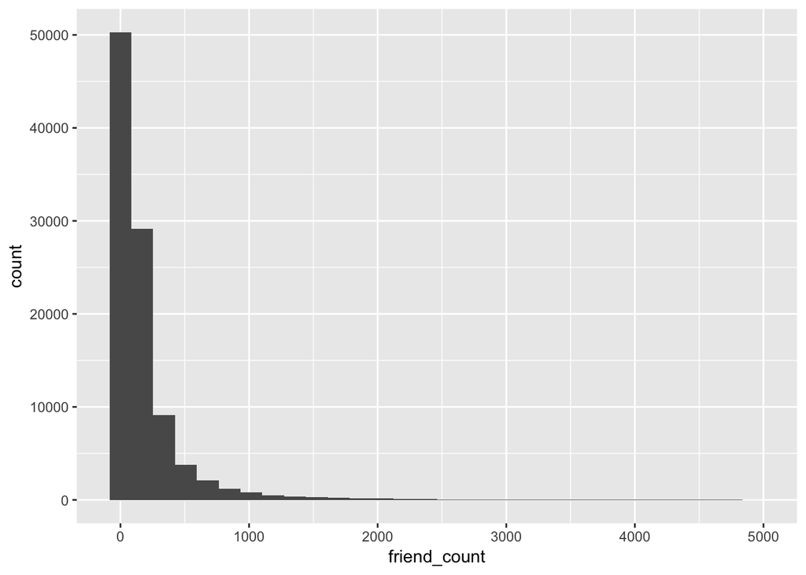

```r
ggplot(data = pf) +
  geom_histogram(mapping = aes(x = friend_count))
```

#### How is this plot similar to Moira’s first plot?

Response:

### Limiting the Axes

Notes:

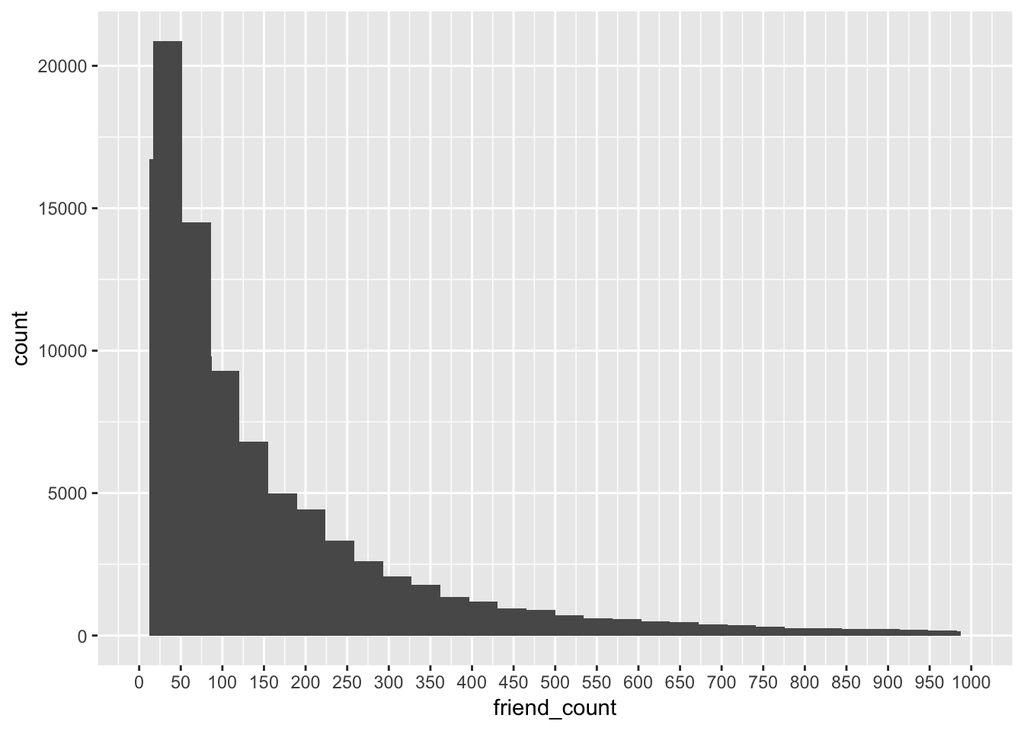

```r
ggplot(data = pf, mapping = aes(x = friend_count)) +
  geom_histogram() +
  scale_x_continuous(limits = c(0,1000),
                     breaks = seq(0,1000,50)) +
  stat_bin(binwidth = 25)
```

### Faceting Friend Count

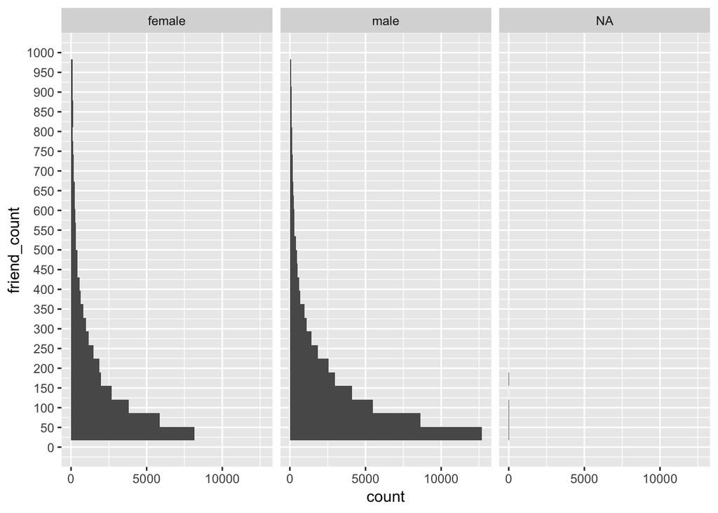

```r
# What code would you add to create a facet the histogram by gender?
# Add it to the code below.
ggplot(data = pf, mapping = aes(x = friend_count)) +
  geom_histogram() +
  scale_x_continuous(limits = c(0, 1000),
                     breaks = seq(0, 1000, 50)) +
  facet_wrap(~gender) +
  coord_flip()
```

### Omitting NA Values

Notes:

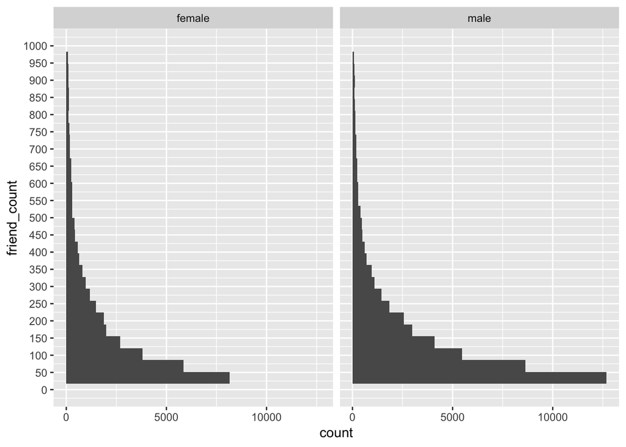

```r
ggplot(data = subset(pf, !is.na(pf$gender)),
       mapping = aes(x = friend_count)) +
  geom_histogram() +
  scale_x_continuous(limits = c(0, 1000),
                     breaks = seq(0, 1000, 50)) +
  facet_wrap(~gender) +
  coord_flip()
```

### Statistics ‘by’ Gender

Notes:

```r
table(pf$gender)
```

```
##
## female   male
##  40254  58574
```

```r
by(pf$friend_count, pf$gender, summary)
```

```
## pf$gender: female
##    Min. 1st Qu.  Median    Mean 3rd Qu.    Max.
##       0      37      96     242     244    4923
## --------------------------------------------------------
## pf$gender: male
##    Min. 1st Qu.  Median    Mean 3rd Qu.    Max.
##       0      27      74     165     182    4917
```

#### Who on average has more friends: men or women?

Response: Women

#### What’s the difference between the median friend count for women and men?

Response: 22

#### Why would the median be a better measure than the mean?

Response: Number of samples does not affect it

### Tenure

Notes:

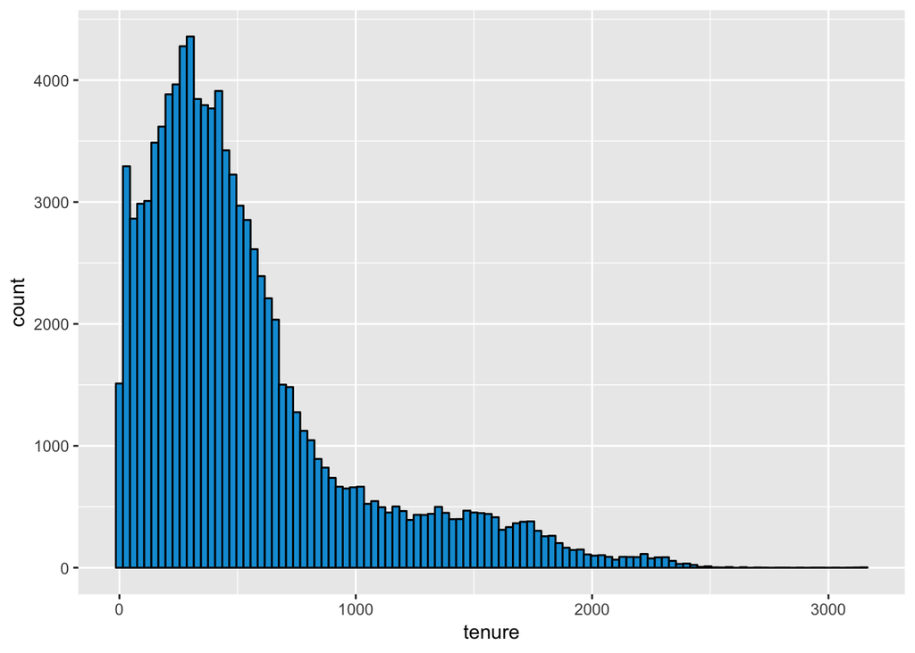

```r
ggplot(aes(x = tenure), data = pf) +
  geom_histogram(binwidth = 30,
                 color = 'black', fill = '#099DD9')
```

#### How would you create a histogram of tenure by year?

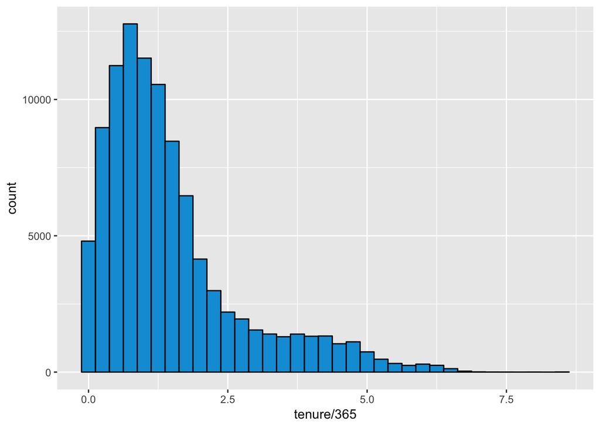

```r
ggplot(aes(x = tenure/365), data = pf) +
  geom_histogram(color = 'black',
                 fill = '#099DD9',
                 binwidth = 0.25)
```

### Labeling Plots

Notes:

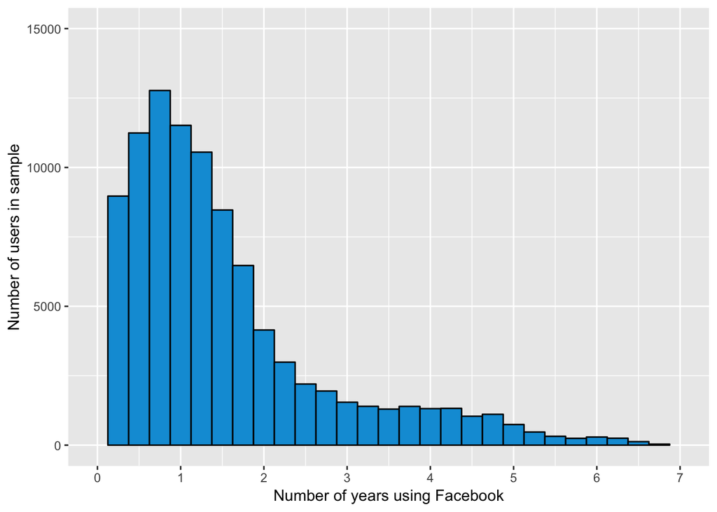

```r
# Histogram with more details and labels
ggplot(aes(x = tenure/365), data = pf) +
  geom_histogram(color = 'black',
                 fill = '#099DD9',
                 binwidth = 0.25, na.rm = TRUE) +
  scale_x_continuous(limits = c(0,7),
                     breaks = seq(0,7,1)) +
  scale_y_continuous(limits = c(0,15000)) +
  xlab('Number of years using Facebook') +
  ylab('Number of users in sample')
```

### User Ages

Notes:

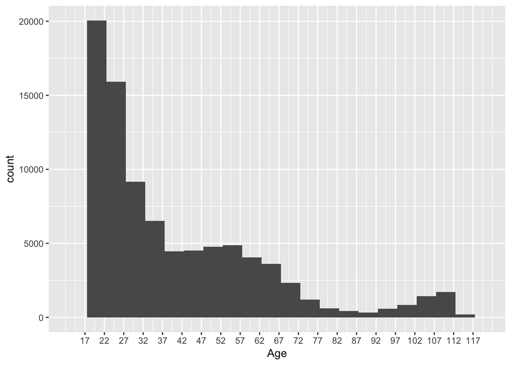

```r
ggplot(data = pf, mapping = aes(x = pf$age)) +
  geom_histogram(binwidth = 5, na.rm = TRUE) +
  scale_x_continuous(limits = c(13,120), breaks = seq(17,120,5)) +
  xlab('Age')
```

***

### The Spread of Memes

Notes: Log Scale was used since the count was in the high 1000’s to identify patterns which were not visible on a normal scale

### Add a Scaling Layer

Notes:

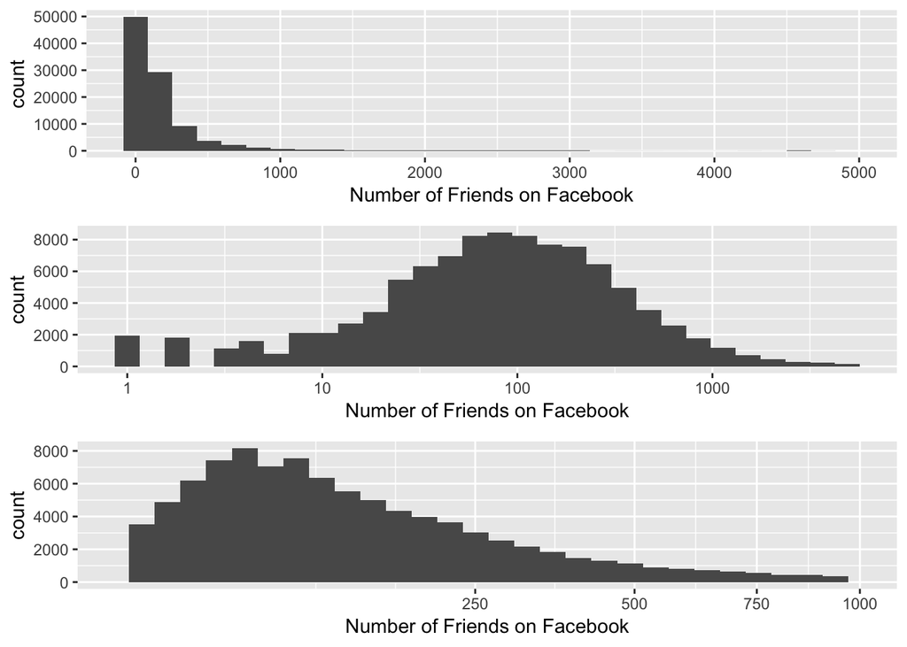

```r
#install.packages('gridExtra')
library(gridExtra)
# Normal Histogram

plot_1 <- ggplot(data = pf, mapping = aes(x = friend_count + 1)) +
  geom_histogram(na.rm = TRUE) + xlab('Number of Friends on Facebook')

# Histogram using log10 transformation
plot_2 <- plot_1 +
  scale_x_log10()

# Histogram using sqrt transformation
plot_3 <- plot_1 +
  scale_x_sqrt(limits = c(1,1000))

grid.arrange(plot_1, plot_2, plot_3)
```

### Frequency Polygons

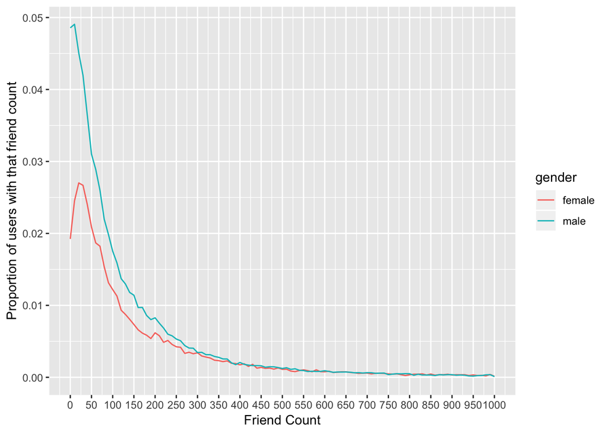

```r
ggplot(aes(x = friend_count + 1, y = ..count../sum(..count..)),
       data = subset(pf, !is.na(gender))) +
  geom_freqpoly(na.rm = TRUE ,aes(color = gender), binwidth=10) +
  scale_x_continuous(limits = c(0, 1000), breaks = seq(0, 1000, 50)) +
  xlab('Friend Count') +
  ylab('Proportion of users with that friend count')
```

### Likes on the Web

Notes:

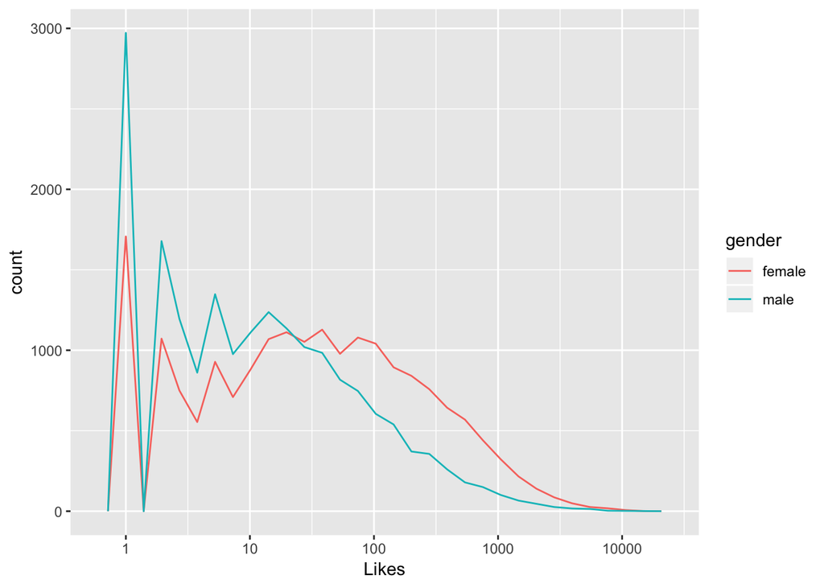

```r
ggplot(aes(x = www_likes), data = subset(pf, !is.na(gender))) +
  geom_freqpoly(aes(color = gender)) +
  scale_x_continuous() +
  scale_x_log10() +
  xlab('Likes')
```

### Box Plots

Notes:

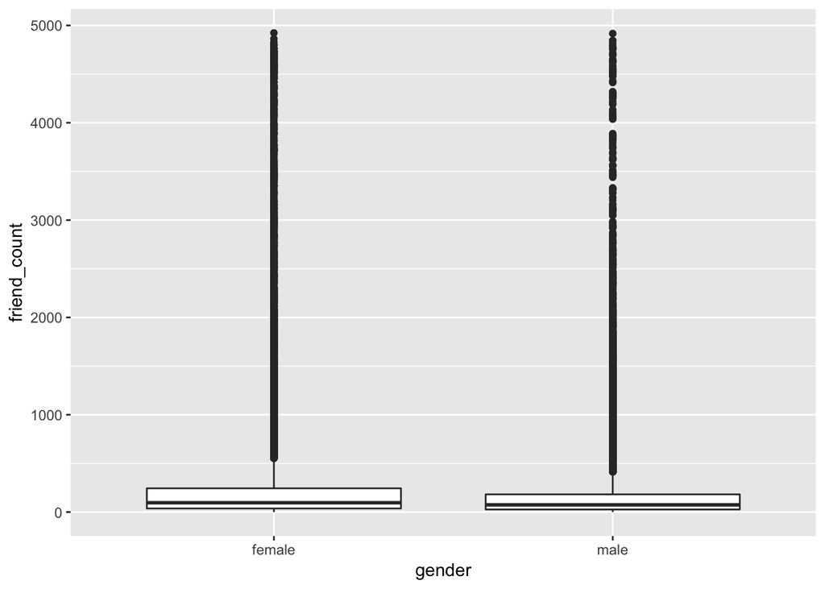

```r
ggplot(data = subset(pf, !is.na(pf$gender)), mapping = aes(x = gender,y = friend_count)) +
  geom_boxplot()
```

#### Adjust the code to focus on users who have friend counts between 0 and 1000.

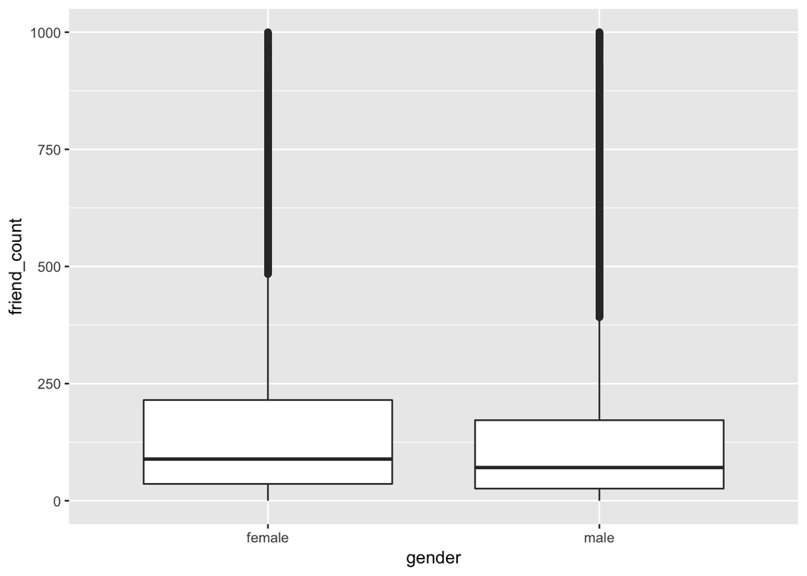

```r
ggplot(data = subset(pf, !is.na(pf$gender)),
       mapping = aes(x = gender,y = friend_count)) +
  geom_boxplot(na.rm = TRUE) +
  scale_y_continuous(limits = c(0,1000))
```

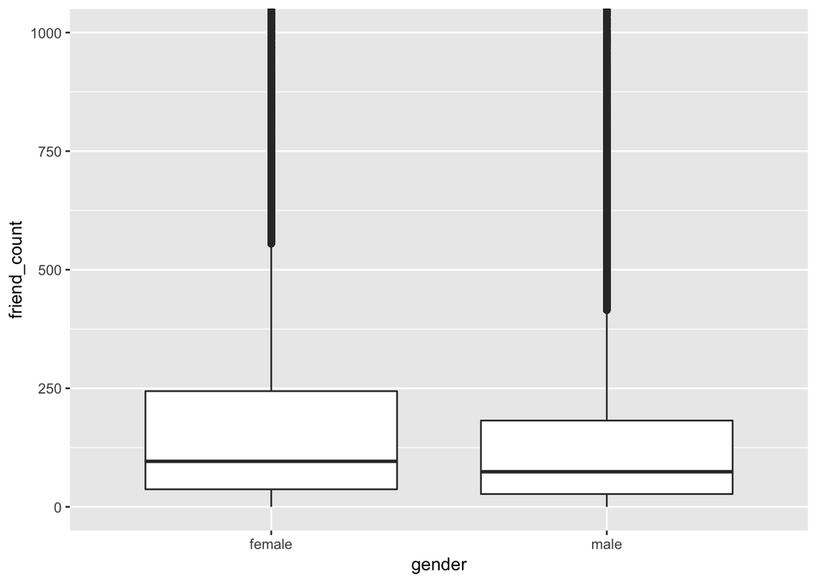

```r
# Using coord_cartesian()

ggplot(data = subset(pf, !is.na(pf$gender)),
       mapping = aes(x = gender,y = friend_count)) +
  geom_boxplot(na.rm = TRUE) +
  coord_cartesian(ylim = c(0,1000))
```

### Box Plots, Quartiles, and Friendships

Notes:

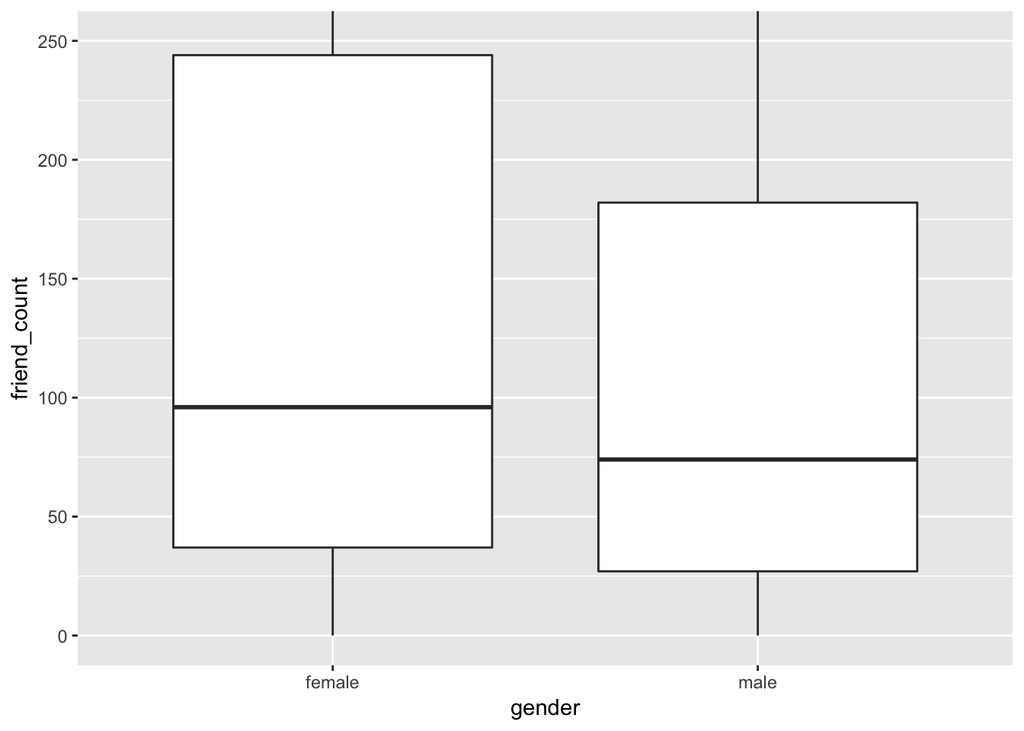

```r
ggplot(data = subset(pf, !is.na(pf$gender)),
       mapping = aes(x = gender,y = friend_count)) +
  geom_boxplot(na.rm = TRUE) +
  coord_cartesian(ylim = c(0,250))
```

```r
by(pf$friend_count, pf$gender, summary)
```

```
## pf$gender: female
##    Min. 1st Qu.  Median    Mean 3rd Qu.    Max.
##       0      37      96     242     244    4923
## --------------------------------------------------------
## pf$gender: male
##    Min. 1st Qu.  Median    Mean 3rd Qu.    Max.
##       0      27      74     165     182    4917
```

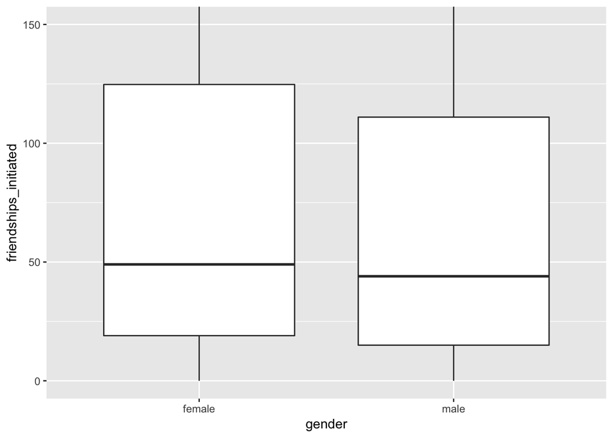

```r
ggplot(data = subset(pf, !is.na(pf$gender)),
       mapping = aes(x = gender,y = friendships_initiated)) +
  geom_boxplot(na.rm = TRUE) +
  coord_cartesian(ylim = c(0,150))
```

#### On average, who initiated more friendships in our sample: men or women?

Response: From plot 3, women have initiated more friendships by just a small margin #### Write about some ways that you can verify your answer. Response: The boxplot can be used to verify the same

```r
by(pf$friendships_initiated, pf$gender, summary)
```

```
## pf$gender: female
##    Min. 1st Qu.  Median    Mean 3rd Qu.    Max.
##     0.0    19.0    49.0   113.9   124.8  3654.0
## --------------------------------------------------------
## pf$gender: male
##    Min. 1st Qu.  Median    Mean 3rd Qu.    Max.
##     0.0    15.0    44.0   103.1   111.0  4144.0
```

Response: Female have initiated more friendships

### Getting Logical

Notes:

```r
summary(pf$mobile_likes)
```

```
##    Min. 1st Qu.  Median    Mean 3rd Qu.    Max.
##     0.0     0.0     4.0   106.1    46.0 25111.0
```

```r
summary(pf$mobile_likes > 0)
```

```
##    Mode   FALSE    TRUE
## logical   35056   63947
```

```r
mobile_check_in <- NA
pf$mobile_check_in <- ifelse(pf$mobile_likes > 0, 1, 0)
pf$mobile_check_in <- factor(pf$mobile_check_in)
# Calculating Percentage
round(summary(pf$mobile_check_in)/ length(pf$mobile_check_in) * 100,2)
```

```
##     0     1
## 35.41 64.59
```

Response: More people use mobile check in according to this sample we have at hand